# W241 Class Project - Analysis

# 1. Load libraries, data

Load up the data and do simple analysis. This version uses the complete dataset.

```r
# Libraries
library(lmtest)
library(sandwich)
library(ggplot2)
library(data.table)
library(stargazer)
library(ri)
library(multiwayvcov)
library(AER)

rm(list=ls())

d <- read.csv('~/Documents/mids-w241-final/Analysis/Combined Log.csv')
#d <- read.csv("C:/Users/Chris/OneDrive/Documents/MIDS/WS241/final/mids-w241-final/Analysis/Combined Log.csv")

d <- data.table(d)
# d <- d[complete.cases(d),] drops any row that is incomplete - too stringent since we have some cols which are not essential
d <- d[!is.na(no)] # Just drop row with missing values
# d <- d[complete.cases(d),] drops any row that is too incomplete - too stringent since we have some cols which are not essential
#d <- d[!is.na(no)] # Just drop row with missing values

# Base data
head(d)

# Convert, transform data for analysis

# Drop some cols
d[,c('title','full_URL', 'reply_email_TO_BE_FILLED_IN_standard','posting_ID','notes') :=NULL]

# Set gender = 1 for Jane
d[treatment_assignment=='Jane_Control' | treatment_assignment=='Jane_Treat_High' | treatment_assignment=='Jane_Treat_Low',gender:=1]
d[treatment_assignment=='John_Control' | treatment_assignment=='John_Treat_High' | treatment_assignment=='John_Treat_Low',gender:=0]

# Set treatment variable = 0 for control, 1 for low, 2 for high (treatment here is continuous)
d[treatment_assignment=='Jane_Control' | treatment_assignment=='John_Control', treatment:=0]
d[treatment_assignment=='Jane_Treat_Low' | treatment_assignment=='John_Treat_Low', treatment:=1]
d[treatment_assignment=='Jane_Treat_High' | treatment_assignment=='John_Treat_High', treatment:=2]

# Alternatively, treat treatment types as categorical variables instead of continuous
d[treatment_assignment=='Jane_Treat_Low' | treatment_assignment=='John_Treat_Low', low_treatment:=1]
d[treatment_assignment=='Jane_Treat_High' | treatment_assignment=='John_Treat_High', high_treatment:=1]
d$low_treatment[is.na(d$low_treatment)] <- 0
d$high_treatment[is.na(d$high_treatment)] <- 0

d[low_treatment==1 | high_treatment==0, assigned:=1]
d$assigned[is.na(d$assigned)] <- 0

# Capture complier
#d[sent!='', compliers:=1]
#d$compliers[is.na(d$compliers)] <- 0

# Labeling data
d$gender <- factor(d$gender,labels = c("Male", "Female"))
d$outcome_f <- factor(d$outcome, labels = c("No Response", "Response"))
d$bedrooms <- factor(d$bedrooms, labels = c("1-bedroom", "2-bedroom"))
d$professional <- factor(d$professional, labels = c("Non-professional", "Professional"))
d$treatment_f <- factor(d$treatment, labels = c("Control","Low","High"))

head(d)
```

[output not shown]

# 2. Check data, do simple tables to check for balance

Recode missing sqft values. It’s not necessary but we use this in some of our model specifications.

```r
# Recode missing sqft with mean of cluster (city)
d[, Mean:=mean(sqft, na.rm=TRUE), by=city]
d[is.na(sqft)]$sqft <- d[is.na(sqft)]$Mean
d[,c('Mean') :=NULL]
```

Remove duplicate emails

```r
# If duplicate, only retain first email sent, sets up for exploration later
d <- d[duplicate_email == 0]
```

For the most part it looks like we have a balanced dataset.

```r
cat('Table of Outcomes:')
```

```
## Table of Outcomes:
```

```r
table(d$outcome_f)
```

```
##
## No Response    Response
##         256         207
```

```r
cat('\nTable of Outcomes (By Gender):')
```

```
##
## Table of Outcomes (By Gender):
```

```r
table(d$outcome_f, d$gender)
```

```
##
##               Male Female
##   No Response  131    125
##   Response     100    107
```

```r
cat('\nTable of Outcomes (By Treatment):')
```

```
##
## Table of Outcomes (By Treatment):
```

```r
table(d$outcome_f, d$treatment_f)
```

```
##
##               Control Low High
##   No Response      87  87   82
##   Response         68  68   71
```

```r
cat('\nTable of Outcomes (By Treatment and Gender):')
```

```
##
## Table of Outcomes (By Treatment and Gender):
```

```r
table(d$outcome_f, factor(d$treatment_assignment))
```

```
##
##               Jane_Control Jane_Treat_High Jane_Treat_Low John_Control
##   No Response           39              38             48           48
##   Response              38              37             32           30
##
##               John_Treat_High John_Treat_Low
##   No Response              44             39
##   Response                 34             36
```

```r
cat('\nTable of Outcomes (By City):')
```

```
##
## Table of Outcomes (By City):
```

```r
table(d$outcome_f,factor(d$city))
```

```
##
##               chicago houston sandiego seattle
##   No Response      63      78       65      50
##   Response         61      38       51      57
```

```r
cat('\nTable of Outcomes (By Rooms):')
```

```
##
## Table of Outcomes (By Rooms):
```

```r
table(d$outcome_f,factor(d$bedrooms))
```

```
##
##               1-bedroom 2-bedroom
##   No Response       125       131
##   Response           96       111
```

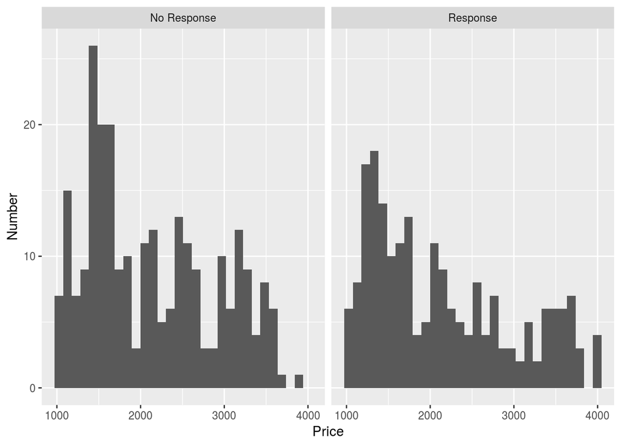

```r
ggplot(d,aes(x=price))+geom_histogram()+facet_grid(~outcome_f)+labs(x="Price",y="Number")
```

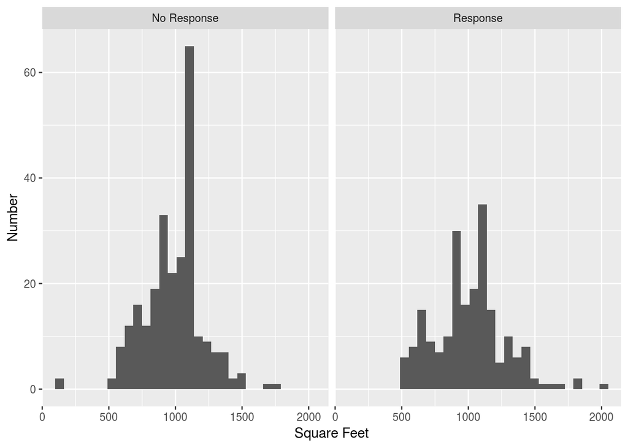

```r
# Sqft info has missing values => we can drop all cases (see above) but for now leave this alone or we use the clustering estimate
# Similar but somewhat worse issue for professional, same.email info

ggplot(d,aes(x=sqft))+geom_histogram()+facet_grid(~outcome_f)+labs(x="Square Feet",y="Number")
```

```r
cat('\nTable of Outcomes (By Professional):')
```

```
##
## Table of Outcomes (By Professional):
```

```r
table(d$outcome_f,factor(d$professional))
```

```
##
##               Non-professional Professional
##   No Response               55          201
##   Response                  35          172
```

# 3. Analysis

# Simple Analysis

We do a chi-squared test of independence to see if the observations are independent. We cannot reject the hypothesis that the observations are indpendent. This is true for even the professional category.

```r
# For Outcome and Gender
tbl <- table(d$outcome_f,d$gender)
tbl
```

```
##
##               Male Female
##   No Response  131    125
##   Response     100    107
```

```r
chisq.test(tbl)
```

```
##
##  Pearson's Chi-squared test with Yates' continuity correction
##
## data:  tbl
## X-squared = 0.26941, df = 1, p-value = 0.6037
```

```r
# On Outcome and Treatment
tbl <- table(d$outcome_f,d$treatment)
tbl
```

```
##
##                0  1  2
##   No Response 87 87 82
##   Response    68 68 71
```

```r
chisq.test(tbl)
```

```
##
##  Pearson's Chi-squared test
##
## data:  tbl
## X-squared = 0.26615, df = 2, p-value = 0.8754
```

```r
# On Outcome and Treatment Assignment
tbl <- table(d$outcome_f,factor(d$treatment_assignment))
tbl
```

```
##
##               Jane_Control Jane_Treat_High Jane_Treat_Low John_Control
##   No Response           39              38             48           48
##   Response              38              37             32           30
##
##               John_Treat_High John_Treat_Low
##   No Response              44             39
##   Response                 34             36
```

```r
chisq.test(tbl)
```

```
##
##  Pearson's Chi-squared test
##
## data:  tbl
## X-squared = 3.6372, df = 5, p-value = 0.6027
```

```r
# On Outcome and Professional
tbl <- table(d$outcome_f,d$professional)
tbl
```

```
##
##               Non-professional Professional
##   No Response               55          201
##   Response                  35          172
```

```r
chisq.test(tbl)
```

```
##
##  Pearson's Chi-squared test with Yates' continuity correction
##
## data:  tbl
## X-squared = 1.2523, df = 1, p-value = 0.2631
```

# Regression

We run regression on treatment as a factor (control, low, high) with and without gender as another factor. Other co-variates are added including city, price, bedrooms.

Basic model

```
Outcome variable = alpha + B_high + B_low + gender + covariates
```

```r
# First we treat treatment as a continous variable

# Model 1a - Basic model
m1 <- lm(outcome~treatment,data=d)
stargazer(m1,type='text')
```

```
##
## ===============================================
##                         Dependent variable:
##                     ---------------------------
##                               outcome
## -----------------------------------------------
## treatment                      0.013
##                               (0.028)
##
## Constant                     0.434***
##                               (0.037)
##
## -----------------------------------------------
## Observations                    463
## R2                            0.0004
## Adjusted R2                   -0.002
## Residual Std. Error      0.498 (df = 461)
## F Statistic             0.198 (df = 1; 461)
## ===============================================
## Note:               *p<0.1; **p<0.05; ***p<0.01
```

```r
coeftest(m1, vcovHC(m1)) # Robust se
```

```
##
## t test of coefficients:
##
##             Estimate Std. Error t value Pr(>|t|)
## (Intercept) 0.434495   0.036582 11.8771   <2e-16 ***
## treatment   0.012644   0.028502  0.4436   0.6575
## ---
## Signif. codes:  0 '***' 0.001 '**' 0.01 '*' 0.05 '.' 0.1 ' ' 1
```

```r
# Model 2a - Treatment & gender
m2 <- lm(outcome~treatment*gender,data=d)
stargazer(m2,type='text')
```

```
##
## ==================================================
##                            Dependent variable:
##                        ---------------------------
##                                  outcome
## --------------------------------------------------
## treatment                         0.026
##                                  (0.040)
##
## genderFemale                      0.054
##                                  (0.073)
##
## treatment:genderFemale           -0.026
##                                  (0.057)
##
## Constant                        0.407***
##                                  (0.052)
##
## --------------------------------------------------
## Observations                       463
## R2                                0.002
## Adjusted R2                      -0.005
## Residual Std. Error         0.499 (df = 459)
## F Statistic                0.262 (df = 3; 459)
## ==================================================
## Note:                  *p<0.1; **p<0.05; ***p<0.01
```

```r
coeftest(m2, vcovHC(m2)) # Robust se
```

```
##
## t test of coefficients:
##
##                         Estimate Std. Error t value  Pr(>|t|)
## (Intercept)             0.407259   0.051210  7.9527 1.434e-14 ***
## treatment               0.025641   0.039798  0.6443    0.5197
## genderFemale            0.054454   0.073288  0.7430    0.4579
## treatment:genderFemale -0.026152   0.057200 -0.4572    0.6477
## ---
## Signif. codes:  0 '***' 0.001 '**' 0.01 '*' 0.05 '.' 0.1 ' ' 1
```

```r
# Model 3a - Treatment & gender + covariates
m3 <- lm(outcome~treatment*gender+factor(city)+factor(bedrooms)+price,data=d)
stargazer(m3,type='text')
```

```
##
## =====================================================
##                               Dependent variable:
##                           ---------------------------
##                                     outcome
## -----------------------------------------------------
## treatment                            0.027
##                                     (0.040)
##
## genderFemale                         0.052
##                                     (0.073)
##
## factor(city)houston                -0.164**
##                                     (0.064)
##
## factor(city)sandiego                -0.051
##                                     (0.064)
##
## factor(city)seattle                  0.042
##                                     (0.066)
##
## factor(bedrooms)2-bedroom            0.027
##                                     (0.050)
##
## price                              -0.00000
##                                    (0.00003)
##
## treatment:genderFemale              -0.025
##                                     (0.057)
##
## Constant                           0.441***
##                                     (0.088)
##
## -----------------------------------------------------
## Observations                          463
## R2                                   0.026
## Adjusted R2                          0.009
## Residual Std. Error            0.496 (df = 454)
## F Statistic                   1.516 (df = 8; 454)
## =====================================================
## Note:                     *p<0.1; **p<0.05; ***p<0.01
```

```r
coeftest(m3, vcovHC(m3)) # Robust se
```

```
##
## t test of coefficients:
##
##                              Estimate  Std. Error t value  Pr(>|t|)
## (Intercept)                4.4134e-01  9.0292e-02  4.8880 1.416e-06 ***
## treatment                  2.7172e-02  3.9686e-02  0.6847   0.49389
## genderFemale               5.2129e-02  7.3091e-02  0.7132   0.47609
## factor(city)houston       -1.6386e-01  6.3923e-02 -2.5633   0.01069 *
## factor(city)sandiego      -5.1371e-02  6.5858e-02 -0.7800   0.43578
## factor(city)seattle        4.2490e-02  6.7313e-02  0.6312   0.52821
## factor(bedrooms)2-bedroom  2.7215e-02  4.9288e-02  0.5522   0.58111
## price                     -2.4420e-06  3.1488e-05 -0.0776   0.93822
## treatment:genderFemale    -2.4833e-02  5.7221e-02 -0.4340   0.66451
## ---
## Signif. codes:  0 '***' 0.001 '**' 0.01 '*' 0.05 '.' 0.1 ' ' 1
```

```r
# Model 3a-1 - Treatment & gender + all covariates including less reliable sqft and professoinal
m3.1 <- lm(outcome~treatment*gender+factor(city)+factor(bedrooms)+price+sqft+professional,data=d)
stargazer(m3.1,type='text')
```

```
##
## =====================================================
##                               Dependent variable:
##                           ---------------------------
##                                     outcome
## -----------------------------------------------------
## treatment                            0.026
##                                     (0.040)
##
## genderFemale                         0.059
##                                     (0.073)
##
## factor(city)houston                -0.181***
##                                     (0.067)
##
## factor(city)sandiego                -0.031
##                                     (0.068)
##
## factor(city)seattle                  0.051
##                                     (0.071)
##
## factor(bedrooms)2-bedroom           -0.009
##                                     (0.055)
##
## price                              -0.00003
##                                    (0.00003)
##
## sqft                                0.0002*
##                                    (0.0001)
##
## professionalProfessional            0.124**
##                                     (0.062)
##
## treatment:genderFemale              -0.027
##                                     (0.057)
##
## Constant                             0.193
##                                     (0.144)
##
## -----------------------------------------------------
## Observations                          463
## R2                                   0.039
## Adjusted R2                          0.018
## Residual Std. Error            0.493 (df = 452)
## F Statistic                  1.832* (df = 10; 452)
## =====================================================
## Note:                     *p<0.1; **p<0.05; ***p<0.01
```

```r
coeftest(m3.1, vcovHC(m3.1)) # Robust se
```

```
##
## t test of coefficients:
##
##                              Estimate  Std. Error t value Pr(>|t|)
## (Intercept)                1.9334e-01  1.4554e-01  1.3285  0.18470
## treatment                  2.6110e-02  3.9819e-02  0.6557  0.51235
## genderFemale               5.9426e-02  7.2995e-02  0.8141  0.41601
## factor(city)houston       -1.8053e-01  6.6516e-02 -2.7141  0.00690 **
## factor(city)sandiego      -3.0741e-02  6.9931e-02 -0.4396  0.66044
## factor(city)seattle        5.0970e-02  7.2326e-02  0.7047  0.48134
## factor(bedrooms)2-bedroom -8.6209e-03  5.3405e-02 -0.1614  0.87183
## price                     -3.0499e-05  3.4144e-05 -0.8932  0.37220
## sqft                       2.2319e-04  1.2288e-04  1.8164  0.06998 .
## professionalProfessional   1.2359e-01  6.3672e-02  1.9410  0.05288 .
## treatment:genderFemale    -2.6580e-02  5.7256e-02 -0.4642  0.64271
## ---
## Signif. codes:  0 '***' 0.001 '**' 0.01 '*' 0.05 '.' 0.1 ' ' 1
```

```r
# Next we treat treatment as a categorical variable (effect might not be linear)

# Model 1b - Basic model
m4 <- lm(outcome~treatment_f,data=d)
stargazer(m4,type='text')
```

```
##
## ===============================================
##                         Dependent variable:
##                     ---------------------------
##                               outcome
## -----------------------------------------------
## treatment_fLow                 0.000
##                               (0.057)
##
## treatment_fHigh                0.025
##                               (0.057)
##
## Constant                     0.439***
##                               (0.040)
##
## -----------------------------------------------
## Observations                    463
## R2                             0.001
## Adjusted R2                   -0.004
## Residual Std. Error      0.499 (df = 460)
## F Statistic             0.132 (df = 2; 460)
## ===============================================
## Note:               *p<0.1; **p<0.05; ***p<0.01
```

```r
coeftest(m4, vcovHC(m4)) # Robust se
```

```
##
## t test of coefficients:
##
##                   Estimate Std. Error t value Pr(>|t|)
## (Intercept)     4.3871e-01 4.0117e-02 10.9358   <2e-16 ***
## treatment_fLow  2.4600e-16 5.6734e-02  0.0000   1.0000
## treatment_fHigh 2.5343e-02 5.7065e-02  0.4441   0.6572
## ---
## Signif. codes:  0 '***' 0.001 '**' 0.01 '*' 0.05 '.' 0.1 ' ' 1
```

```r
# Model 2b - Treatment & gender
m5 <- lm(outcome~treatment_f*gender,data=d)
stargazer(m5,type='text')
```

```
##
## ========================================================
##                                  Dependent variable:
##                              ---------------------------
##                                        outcome
## --------------------------------------------------------
## treatment_fLow                          0.095
##                                        (0.081)
##
## treatment_fHigh                         0.051
##                                        (0.080)
##
## genderFemale                            0.109
##                                        (0.080)
##
## treatment_fLow:genderFemale            -0.189*
##                                        (0.113)
##
## treatment_fHigh:genderFemale           -0.051
##                                        (0.114)
##
## Constant                              0.385***
##                                        (0.056)
##
## --------------------------------------------------------
## Observations                             463
## R2                                      0.008
## Adjusted R2                            -0.003
## Residual Std. Error               0.498 (df = 457)
## F Statistic                      0.724 (df = 5; 457)
## ========================================================
## Note:                        *p<0.1; **p<0.05; ***p<0.01
```

```r
coeftest(m5, vcovHC(m5)) # Robust se
```

```
##
## t test of coefficients:
##
##                               Estimate Std. Error t value  Pr(>|t|)
## (Intercept)                   0.384615   0.055801  6.8926 1.827e-11 ***
## treatment_fLow                0.095385   0.080823  1.1802   0.23855
## treatment_fHigh               0.051282   0.079678  0.6436   0.52015
## genderFemale                  0.108891   0.080287  1.3563   0.17568
## treatment_fLow:genderFemale  -0.188891   0.113758 -1.6605   0.09751 .
## treatment_fHigh:genderFemale -0.051455   0.114474 -0.4495   0.65329
## ---
## Signif. codes:  0 '***' 0.001 '**' 0.01 '*' 0.05 '.' 0.1 ' ' 1
```

```r
# Model 3b - Treatment & gender + covariates
m6 <- lm(outcome~treatment_f*gender+factor(city)+factor(bedrooms)+price,data=d)
stargazer(m6,type='text')
```

```
##
## ========================================================
##                                  Dependent variable:
##                              ---------------------------
##                                        outcome
## --------------------------------------------------------
## treatment_fLow                          0.099
##                                        (0.080)
##
## treatment_fHigh                         0.054
##                                        (0.079)
##
## genderFemale                            0.109
##                                        (0.080)
##
## factor(city)houston                   -0.169***
##                                        (0.064)
##
## factor(city)sandiego                   -0.053
##                                        (0.064)
##
## factor(city)seattle                     0.038
##                                        (0.066)
##
## factor(bedrooms)2-bedroom               0.028
##                                        (0.050)
##
## price                                 -0.00000
##                                       (0.00003)
##
## treatment_fLow:genderFemale            -0.194*
##                                        (0.113)
##
## treatment_fHigh:genderFemale           -0.049
##                                        (0.113)
##
## Constant                              0.419***
##                                        (0.092)
##
## --------------------------------------------------------
## Observations                             463
## R2                                      0.033
## Adjusted R2                             0.011
## Residual Std. Error               0.495 (df = 452)
## F Statistic                     1.527 (df = 10; 452)
## ========================================================
## Note:                        *p<0.1; **p<0.05; ***p<0.01
```

```r
coeftest(m6, vcovHC(m6)) # Robust se
```

```
##
## t test of coefficients:
##
##                                 Estimate  Std. Error t value Pr(>|t|)
## (Intercept)                   4.1906e-01  9.4500e-02  4.4345 1.16e-05 ***
## treatment_fLow                9.8680e-02  8.0530e-02  1.2254 0.221067
## treatment_fHigh               5.4357e-02  7.9457e-02  0.6841 0.494254
## genderFemale                  1.0870e-01  8.0054e-02  1.3578 0.175197
## factor(city)houston          -1.6851e-01  6.3987e-02 -2.6335 0.008742 **
## factor(city)sandiego         -5.3147e-02  6.6088e-02 -0.8042 0.421713
## factor(city)seattle           3.8055e-02  6.7536e-02  0.5635 0.573391
## factor(bedrooms)2-bedroom     2.8279e-02  4.9665e-02  0.5694 0.569366
## price                        -1.8808e-06  3.1555e-05 -0.0596 0.952499
## treatment_fLow:genderFemale  -1.9405e-01  1.1360e-01 -1.7081 0.088303 .
## treatment_fHigh:genderFemale -4.8976e-02  1.1449e-01 -0.4278 0.669017
## ---
## Signif. codes:  0 '***' 0.001 '**' 0.01 '*' 0.05 '.' 0.1 ' ' 1
```

```r
# Model 3b-1 - Treatment & gender + all covariates including less reliable sqft and professoinal
m6.1 <- lm(outcome~treatment*gender+factor(city)+factor(bedrooms)+price+sqft+professional,data=d)
stargazer(m6.1,type='text')
```

```
##
## =====================================================
##                               Dependent variable:
##                           ---------------------------
##                                     outcome
## -----------------------------------------------------
## treatment                            0.026
##                                     (0.040)
##
## genderFemale                         0.059
##                                     (0.073)
##
## factor(city)houston                -0.181***
##                                     (0.067)
##
## factor(city)sandiego                -0.031
##                                     (0.068)
##
## factor(city)seattle                  0.051
##                                     (0.071)
##
## factor(bedrooms)2-bedroom           -0.009
##                                     (0.055)
##
## price                              -0.00003
##                                    (0.00003)
##
## sqft                                0.0002*
##                                    (0.0001)
##
## professionalProfessional            0.124**
##                                     (0.062)
##
## treatment:genderFemale              -0.027
##                                     (0.057)
##
## Constant                             0.193
##                                     (0.144)
##
## -----------------------------------------------------
## Observations                          463
## R2                                   0.039
## Adjusted R2                          0.018
## Residual Std. Error            0.493 (df = 452)
## F Statistic                  1.832* (df = 10; 452)
## =====================================================
## Note:                     *p<0.1; **p<0.05; ***p<0.01
```

```r
coeftest(m6.1, vcovHC(m6.1)) # Robust se
```

```
##
## t test of coefficients:
##
##                              Estimate  Std. Error t value Pr(>|t|)
## (Intercept)                1.9334e-01  1.4554e-01  1.3285  0.18470
## treatment                  2.6110e-02  3.9819e-02  0.6557  0.51235
## genderFemale               5.9426e-02  7.2995e-02  0.8141  0.41601
## factor(city)houston       -1.8053e-01  6.6516e-02 -2.7141  0.00690 **
## factor(city)sandiego      -3.0741e-02  6.9931e-02 -0.4396  0.66044
## factor(city)seattle        5.0970e-02  7.2326e-02  0.7047  0.48134
## factor(bedrooms)2-bedroom -8.6209e-03  5.3405e-02 -0.1614  0.87183
## price                     -3.0499e-05  3.4144e-05 -0.8932  0.37220
## sqft                       2.2319e-04  1.2288e-04  1.8164  0.06998 .
## professionalProfessional   1.2359e-01  6.3672e-02  1.9410  0.05288 .
## treatment:genderFemale    -2.6580e-02  5.7256e-02 -0.4642  0.64271
## ---
## Signif. codes:  0 '***' 0.001 '**' 0.01 '*' 0.05 '.' 0.1 ' ' 1
```

```r
# We try an alternative specification for treatment (as dummy variables)

# Model 1c - Basic model
m7 <- lm(outcome ~ low_treatment + high_treatment, data=d)
stargazer(m7, type='text')
```

```
##
## ===============================================
##                         Dependent variable:
##                     ---------------------------
##                               outcome
## -----------------------------------------------
## low_treatment                  0.000
##                               (0.057)
##
## high_treatment                 0.025
##                               (0.057)
##
## Constant                     0.439***
##                               (0.040)
##
## -----------------------------------------------
## Observations                    463
## R2                             0.001
## Adjusted R2                   -0.004
## Residual Std. Error      0.499 (df = 460)
## F Statistic             0.132 (df = 2; 460)
## ===============================================
## Note:               *p<0.1; **p<0.05; ***p<0.01
```

```r
coeftest(m7, vcovHC(m7)) # Robust se
```

```
##
## t test of coefficients:
##
##                  Estimate Std. Error t value Pr(>|t|)
## (Intercept)    4.3871e-01 4.0117e-02 10.9358   <2e-16 ***
## low_treatment  2.4600e-16 5.6734e-02  0.0000   1.0000
## high_treatment 2.5343e-02 5.7065e-02  0.4441   0.6572
## ---
## Signif. codes:  0 '***' 0.001 '**' 0.01 '*' 0.05 '.' 0.1 ' ' 1
```

```r
# Model 2c - Treatment & gender
m8 <- lm(outcome ~ low_treatment + high_treatment*gender, data=d)
stargazer(m8, type='text')
```

```
##
## =======================================================
##                                 Dependent variable:
##                             ---------------------------
##                                       outcome
## -------------------------------------------------------
## low_treatment                         -0.0003
##                                       (0.057)
##
## high_treatment                         0.004
##                                       (0.075)
##
## genderFemale                           0.014
##                                       (0.057)
##
## high_treatment:genderFemale            0.043
##                                       (0.099)
##
## Constant                             0.432***
##                                       (0.049)
##
## -------------------------------------------------------
## Observations                            463
## R2                                     0.002
## Adjusted R2                           -0.007
## Residual Std. Error              0.499 (df = 458)
## F Statistic                     0.209 (df = 4; 458)
## =======================================================
## Note:                       *p<0.1; **p<0.05; ***p<0.01
```

```r
coeftest(m8, vcovHC(m8)) # Robust se
```

```
##
## t test of coefficients:
##
##                               Estimate Std. Error t value Pr(>|t|)
## (Intercept)                  0.4315100  0.0487008  8.8604   <2e-16 ***
## low_treatment               -0.0002805  0.0569497 -0.0049   0.9961
## high_treatment               0.0043874  0.0748774  0.0586   0.9533
## genderFemale                 0.0144928  0.0569519  0.2545   0.7992
## high_treatment:genderFemale  0.0429431  0.0995078  0.4316   0.6663
## ---
## Signif. codes:  0 '***' 0.001 '**' 0.01 '*' 0.05 '.' 0.1 ' ' 1
```

```r
# Model 3c - Treatment & gender + covariates
m9 <- lm(outcome ~ low_treatment + high_treatment + gender + factor(city) + factor(bedrooms) + price, data=d)
stargazer(m9, type='text')
```

```
##
## =====================================================
##                               Dependent variable:
##                           ---------------------------
##                                     outcome
## -----------------------------------------------------
## low_treatment                       -0.0001
##                                     (0.056)
##
## high_treatment                       0.030
##                                     (0.057)
##
## genderFemale                         0.028
##                                     (0.046)
##
## factor(city)houston                -0.164**
##                                     (0.064)
##
## factor(city)sandiego                -0.051
##                                     (0.064)
##
## factor(city)seattle                  0.043
##                                     (0.066)
##
## factor(bedrooms)2-bedroom            0.027
##                                     (0.050)
##
## price                              -0.00000
##                                    (0.00003)
##
## Constant                           0.460***
##                                     (0.086)
##
## -----------------------------------------------------
## Observations                          463
## R2                                   0.026
## Adjusted R2                          0.009
## Residual Std. Error            0.496 (df = 454)
## F Statistic                   1.503 (df = 8; 454)
## =====================================================
## Note:                     *p<0.1; **p<0.05; ***p<0.01
```

```r
coeftest(m9, vcovHC(m9)) # Robust se
```

```
##
## t test of coefficients:
##
##                              Estimate  Std. Error t value  Pr(>|t|)
## (Intercept)                4.6005e-01  8.8305e-02  5.2097 2.875e-07 ***
## low_treatment             -7.4204e-05  5.6840e-02 -0.0013   0.99896
## high_treatment             3.0033e-02  5.7078e-02  0.5262   0.59902
## genderFemale               2.7675e-02  4.6663e-02  0.5931   0.55343
## factor(city)houston       -1.6363e-01  6.3897e-02 -2.5609   0.01076 *
## factor(city)sandiego      -5.1371e-02  6.5820e-02 -0.7805   0.43552
## factor(city)seattle        4.3446e-02  6.7309e-02  0.6455   0.51895
## factor(bedrooms)2-bedroom  2.7070e-02  4.9295e-02  0.5491   0.58317
## price                     -3.2990e-06  3.1595e-05 -0.1044   0.91689
## ---
## Signif. codes:  0 '***' 0.001 '**' 0.01 '*' 0.05 '.' 0.1 ' ' 1
```

The coefficients on treatment are also statistically insignificant. There is no evidence that exclamation points have an effect.

## Randomization Inference

Next we use randomization inference (assuming a Sharp Null of No Effect) to understand if our observation is consistent with an empirical null distribution. For this, we combine low and high treatment into treatment (since we have not learned more complex fixes for heterogenous effects).

```r
# Combining treatments
di <- d
di[treatment==2,treatment:=1]


# Define distributions
y <- di$outcome
Z <- di$treatment
blk1 <- as.numeric(di$gender) # We block by gender
blk2 <- as.numeric(di$city) # Block by city
blk3 <- as.numeric(di$bedrooms)

# By gender
perms <- genperms(Z, clustvar = NULL, blockvar = blk1)
```

```
## Too many permutations to use exact method.
## Defaulting to approximate method.
## Increase maxiter to at least 4.71723366085152e+125 to perform exact estimation.
```

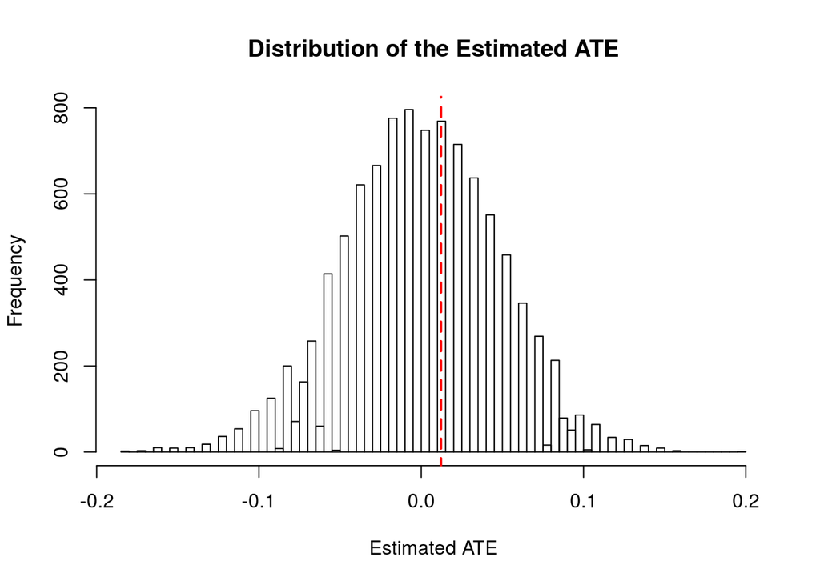

```
## $two.tailed.p.value
## [1] 0.8558
##
## $two.tailed.p.value.abs
## [1] 0.8385
##
## $greater.p.value
## [1] 0.4279
##
## $lesser.p.value
## [1] 0.5782
##
## $quantile
##        2.5%       97.5%
## -0.09458152  0.09040337
##
## $sd
## [1] 0.04919926
##
## $exp.val
## [1] -0.0008509423
```

```r
probs <- genprobexact(Z, clustvar = NULL, blockvar = blk1) # probability of treatment
ate <- estate(y,Z,prob=probs) # estimate the ATE

Ys <- genouts(y,Z,ate=0) # generate potential outcomes under sharp null of no effect
distout <- gendist(Ys,perms, prob=probs) # generate sampling dist. under sharp null
dispdist(distout, ate, quantiles = c(0.025, 0.975), display.plot = TRUE) # display characteristics of sampling dist. for inference
```

```r
# By city
perms <- genperms(Z, clustvar = NULL, blockvar = blk2)
```

```
## Too many permutations to use exact method.
## Defaulting to approximate method.
## Increase maxiter to at least 4.30004626452468e+123 to perform exact estimation.
```

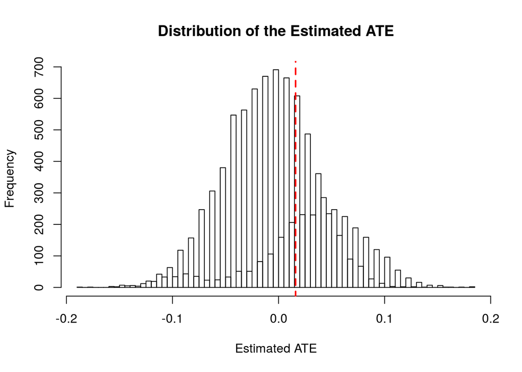

```
## $two.tailed.p.value
## [1] 0.7422
##
## $two.tailed.p.value.abs
## [1] 0.72
##
## $greater.p.value
## [1] 0.3711
##
## $lesser.p.value
## [1] 0.6293
##
## $quantile
##        2.5%       97.5%
## -0.09747162  0.09453373
##
## $sd
## [1] 0.04869454
##
## $exp.val
## [1] 0.0003723622
```

```r
probs <- genprobexact(Z, clustvar = NULL, blockvar = blk2) # probability of treatment
ate <- estate(y,Z,prob=probs) # estimate the ATE

Ys <- genouts(y,Z,ate=0) # generate potential outcomes under sharp null of no effect
distout <- gendist(Ys,perms, prob=probs) # generate sampling dist. under sharp null
dispdist(distout, ate, quantiles = c(0.025, 0.975), display.plot = TRUE) # display characteristics of sampling dist. for inference
```

```r
# By bedroom
perms <- genperms(Z, clustvar = NULL, blockvar = blk3)
```

```
## Too many permutations to use exact method.
## Defaulting to approximate method.
## Increase maxiter to at least 3.99201059514234e+125 to perform exact estimation.
```

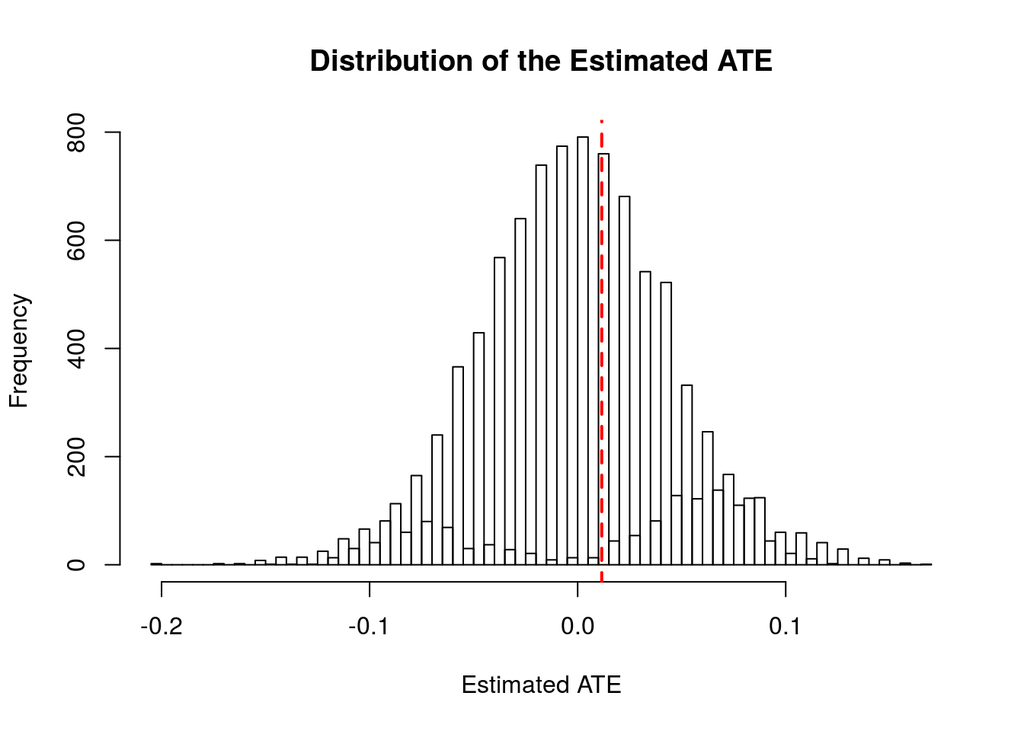

```
## $two.tailed.p.value
## [1] 0.851
##
## $two.tailed.p.value.abs
## [1] 0.8196
##
## $greater.p.value
## [1] 0.4255
##
## $lesser.p.value
## [1] 0.5859
##
## $quantile
##        2.5%       97.5%
## -0.09570224  0.09179664
##
## $sd
## [1] 0.04923477
##
## $exp.val
## [1] 0.0004792098
```

```r
probs <- genprobexact(Z, clustvar = NULL, blockvar = blk3) # probability of treatment
ate <- estate(y,Z,prob=probs) # estimate the ATE

Ys <- genouts(y,Z,ate=0) # generate potential outcomes under sharp null of no effect
distout <- gendist(Ys,perms, prob=probs) # generate sampling dist. under sharp null
dispdist(distout, ate, quantiles = c(0.025, 0.975), display.plot = TRUE) # display characteristics of sampling dist. for inference
```

```r
#P-value for actual data
p.val.actual = sum(abs(distout) > ate) / length(distout)
p.val.actual
```

```
## [1] 0.8082
```

```r
#get respnse rate by treatment or control
actual.response.rate.by.treatment <- di[, mean(outcome), by = c("treatment")]
actual.response.rate.by.treatment
```

```
##    treatment        V1
## 1:         1 0.4512987
## 2:         0 0.4387097
```

```r
di[, sum(outcome > -100), by = c("treatment")]
```

```
##    treatment  V1
## 1:         1 308
## 2:         0 155
```

Once again, we cannot reject the null hypothesis of no effect.

## Other Analysis

1. Although not a signficant issue for this experiement we estimate the CACE. For this we define non-compliers as those for who we sent emails but did not received them - and we know this because we received a “bounced” email message.

```r
# We calculate the CACE manually

# Manually compute CACE
itt <- mean(d$outcome[d$treatment != 0]) - mean(d$outcome[d$treatment == 0])
prop_treated <- 481/483

sprintf("\nThe estimated CACE is: %.5f", itt / prop_treated)
```

```
## [1] "\nThe estimated CACE is: 0.01264"
```

```r
# or 2SLS
#itt_fit <- ivreg(outcome ~treatment,~compliers,data=d)
#stargazer(itt_fit, type='text')
```

```r
# First, we use RI. create a new temp column of outcomes where the share of responses is n%

#To see what treatment response rate is required for significant result, adjust this variable.
#Found that a treatment response rate of about 0.6 would be required to observe significant result
treatment.response.rate <- 0.6
di$hypothetical.outcomes.temp <- sample(c(0,1), size = nrow(d), replace = TRUE, prob = c(1-treatment.response.rate, treatment.response.rate))

#create new outcome column that takes original outcomes for control group, but new hypothetical outcomes with adjusted response rate for treatment rows
di$hypothetical.outcomes = d$outcome
di[treatment==1, hypothetical.outcomes:=hypothetical.outcomes.temp]
fake.response.rate.by.treatment <- di[, mean(hypothetical.outcomes), by = c("treatment")]
fake.response.rate.by.treatment
```

```
##    treatment        V1
## 1:         1 0.5941558
## 2:         0 0.4387097
```

```r
#run RI using the fake data
y.fake <- di$hypothetical.outcomes
Z.fake <- di$treatment
cls.fake <- di$gender
blk.fake <- di$city

perms.fake <- genperms(Z.fake, clustvar = NULL, blockvar = blk.fake)
```

```
## Too many permutations to use exact method.
## Defaulting to approximate method.
## Increase maxiter to at least 4.30004626452468e+123 to perform exact estimation.
```

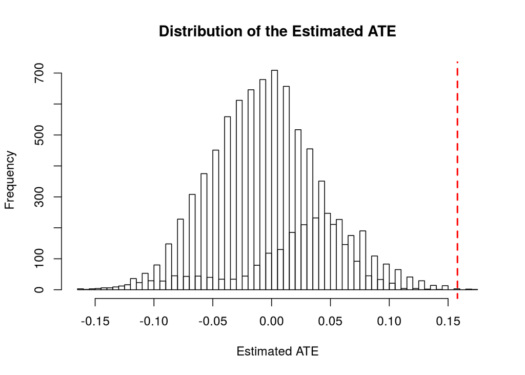

```
## $two.tailed.p.value
## [1] 6e-04
##
## $two.tailed.p.value.abs
## [1] 6e-04
##
## $greater.p.value
## [1] 3e-04
##
## $lesser.p.value
## [1] 0.9997
##
## $quantile
##        2.5%       97.5%
## -0.09596012  0.09754266
##
## $sd
## [1] 0.04933232
##
## $exp.val
## [1] -0.0003398924
```

```r
probs.fake <- genprobexact(Z.fake, clustvar = NULL, blockvar = blk.fake) # probability of treatment
ate.fake <- estate(y.fake,Z.fake,prob=probs.fake) # estimate the ATE

Ys.fake <- genouts(y.fake,Z.fake,ate=0) # generate potential outcomes under sharp null of no effect
distout.fake <- gendist(Ys.fake,perms.fake, prob=probs.fake) # generate sampling dist. under sharp null
dispdist(distout.fake, ate.fake, quantiles = c(0.025, 0.975), display.plot = TRUE) # display characteristics of sampling dist. for inference
```

```r
#P-value for actual data
p.val.fake = sum(abs(distout.fake) > ate.fake) / length(distout.fake)
p.val.fake
```

```
## [1] 6e-04
```

```r
# We can also do this using the regression estimate. For this we use the more general model, m1. Given this model, if we would want to see treatment be statistically significant we either have a larger coefficient or a lower standard error. Choosing a larger n might be one way to reduce the standard error.

z <- coeftest(m1, vcovHC(m1)) # Robust se

# We want Est/Stderr > 2
t.stderr <- z[2]/2
std <- z[4]*sqrt(483)
newn <-(std/t.stderr)^2

sprintf("\nTo attain enough power, i.e. to drive the standard error small enough (all things unchanged), we would need a sample size of %.0f", newn)
```

```
## [1] "\nTo attain enough power, i.e. to drive the standard error small enough (all things unchanged), we would need a sample size of 9817"
```

```r
# Conversely we can also estimate the required difference in coefficient:

newest <- 2*z[4]
sprintf("\nWe need to see an effect of greater than: %.3f", newest)
```

```
## [1] "\nWe need to see an effect of greater than: 0.057"
```

```r
sprintf("Which is about %0.f times more than what we see currently", 2/z[6])
```

```
## [1] "Which is about 5 times more than what we see currently"
```

# 4. Conclusion

Despite running a few different models, we find no evidencce that the number of exclamation points affected response rates to our email.